# Statistical analysis and visualization of functional profiles for genes and gene clusters

Guangchuang Yu School of Basic Medical Sciences, Southern Medical University

2018-10-30

# Abstract

clusterProfiler implements methods to analyze and visualize functional profiles of genomic coordinates (supported by ChIPseeker), gene and gene clusters.

## Supported Analysis

- Over-Representation Analysis
- Gene Set Enrichment Analysis
- Biological theme comparison

## Supported ontologies/pathways

- Disease Ontology (via DOSE)
- [Network of Cancer Gene](http://ncg.kcl.ac.uk/) (via DOSE)
- [DisGeNET](http://www.disgenet.org/web/DisGeNET/menu/home) (via DOSE)
- Gene Ontology (supports many species with GO annotation query online via [AnnotationHub](https://bioconductor.org/packages/AnnotationHub/))
- KEGG Pathway and Module with latest online data (supports more than 4000 species listed in http://www.genome.jp/kegg/catalog/org_list.html)
- Reactome Pathway (via ReactomePA)
- DAVID (via RDAVIDWebService)
- [Molecular Signatures Database](http://software.broadinstitute.org/gsea/msigdb)
  - hallmark gene sets
  - positional gene sets
  - curated gene sets
  - motif gene sets
  - computational gene sets
  - GO gene sets
  - oncogenic signatures
  - immunologic signatures
- Other Annotations
  - from other sources (e.g. [DisGeNET](http://www.disgenet.org/web/DisGeNET/menu/home) as [an example](https://guangchuangyu.github.io/2015/05/use-clusterprofiler-as-an-universal-enrichment-analysis-tool/))
  - user’s annotation
  - customized ontology
  - and many others

## Visualization

- barplot
- cnetplot
- dotplot
- emapplot
- gseaplot
- goplot
- upsetplot

# Citation

If you use clusterProfiler in published research, please cite:

*G Yu*, LG Wang, Y Han, QY He. clusterProfiler: an R package for comparing biological themes among gene clusters. *OMICS: A Journal of Integrative Biology* 2012, 16(5):284-287. doi:[10.1089/omi.2011.0118](http://dx.doi.org/10.1089/omi.2011.0118)

# Introduction

In recently years, high-throughput experimental techniques such as microarray, RNA-Seq and mass spectrometry can detect cellular molecules at systems-level. These kinds of analyses generate huge quantitaties of data, which need to be given a biological interpretation. A commonly used approach is via clustering in the gene dimension for grouping different genes based on their similarities(Yu et al. 2010).

To search for shared functions among genes, a common way is to incorporate the biological knowledge, such as Gene Ontology (GO) and Kyoto Encyclopedia of Genes and Genomes (KEGG), for identifying predominant biological themes of a collection of genes.

After clustering analysis, researchers not only want to determine whether there is a common theme of a particular gene cluster, but also to compare the biological themes among gene clusters. The manual step to choose interesting clusters followed by enrichment analysis on each selected cluster is slow and tedious. To bridge this gap, we designed clusterProfiler(Yu et al. 2012), for comparing and visualizing functional profiles among gene clusters.

# `bitr`: Biological Id TranslatoR

clusterProfiler provides `bitr` and `bitr_kegg` for converting ID types. Both `bitr` and `bitr_kegg` support many species including model and many non-model organisms.

```r
x <- c("GPX3",  "GLRX",   "LBP",   "CRYAB", "DEFB1", "HCLS1",   "SOD2",   "HSPA2",
       "ORM1",  "IGFBP1", "PTHLH", "GPC3",  "IGFBP3","TOB1",    "MITF",   "NDRG1",
       "NR1H4", "FGFR3",  "PVR",   "IL6",   "PTPRM", "ERBB2",   "NID2",   "LAMB1",
       "COMP",  "PLS3",   "MCAM",  "SPP1",  "LAMC1", "COL4A2",  "COL4A1", "MYOC",
       "ANXA4", "TFPI2",  "CST6",  "SLPI",  "TIMP2", "CPM",     "GGT1",   "NNMT",
       "MAL",   "EEF1A2", "HGD",   "TCN2",  "CDA",   "PCCA",    "CRYM",   "PDXK",
       "STC1",  "WARS",  "HMOX1", "FXYD2", "RBP4",   "SLC6A12", "KDELR3", "ITM2B")
eg = bitr(x, fromType="SYMBOL", toType="ENTREZID", OrgDb="org.Hs.eg.db")
head(eg)
```

```
##   SYMBOL ENTREZID
## 1   GPX3     2878
## 2   GLRX     2745
## 3    LBP     3929
## 4  CRYAB     1410
## 5  DEFB1     1672
## 6  HCLS1     3059
```

User should provides an annotation package, both *fromType* and *toType* can accept any types that supported.

User can use *keytypes* to list all supporting types.

```r
library(org.Hs.eg.db)
keytypes(org.Hs.eg.db)
```

```
##  [1] "ACCNUM"       "ALIAS"        "ENSEMBL"      "ENSEMBLPROT"
##  [5] "ENSEMBLTRANS" "ENTREZID"     "ENZYME"       "EVIDENCE"
##  [9] "EVIDENCEALL"  "GENENAME"     "GO"           "GOALL"
## [13] "IPI"          "MAP"          "OMIM"         "ONTOLOGY"
## [17] "ONTOLOGYALL"  "PATH"         "PFAM"         "PMID"
## [21] "PROSITE"      "REFSEQ"       "SYMBOL"       "UCSCKG"
## [25] "UNIGENE"      "UNIPROT"
```

We can translate from one type to other types.

```r
ids <- bitr(x, fromType="SYMBOL", toType=c("UNIPROT", "ENSEMBL"), OrgDb="org.Hs.eg.db")
head(ids)
```

```
##   SYMBOL    UNIPROT         ENSEMBL
## 1   GPX3     P22352 ENSG00000211445
## 2   GLRX A0A024RAM2 ENSG00000173221
## 3   GLRX     P35754 ENSG00000173221
## 4    LBP     P18428 ENSG00000129988
## 5    LBP     Q8TCF0 ENSG00000129988
## 6  CRYAB     P02511 ENSG00000109846
```

For GO analysis, user don’t need to convert ID, all ID type provided by `OrgDb` can be used in `groupGO`, `enrichGO` and `gseGO` by specifying `keyType` parameter.

## `bitr_kegg`: converting biological IDs using KEGG API

```r
data(gcSample)
hg <- gcSample[[1]]
head(hg)
```

```
## [1] "4597"  "7111"  "5266"  "2175"  "755"   "23046"
```

```r
eg2np <- bitr_kegg(hg, fromType='kegg', toType='ncbi-proteinid', organism='hsa')
head(eg2np)
```

```
##    kegg ncbi-proteinid
## 1 10001      NP_005457
## 2 10209      NP_005792
## 3 10232      NP_037536
## 4 10324      NP_006054
## 5 10411   NP_001092002
## 6 10614      NP_006451
```

The ID type (both `fromType` & `toType`) should be one of ‘kegg’, ‘ncbi-geneid’, ‘ncbi-proteinid’ or ‘uniprot’. The ‘kegg’ is the primary ID used in KEGG database. The data source of KEGG was from NCBI. A rule of thumb for the ‘kegg’ ID is `entrezgene` ID for eukaryote species and `Locus` ID for prokaryotes.

Many prokaryote species don’t have entrezgene ID available. For example we can check the gene information of `ece:Z5100` in http://www.genome.jp/dbget-bin/www_bget?ece:Z5100, which have `NCBI-ProteinID` and `UnitProt` links in the `Other DBs` Entry, but not `NCBI-GeneID`.

If we try to convert `Z5100` to `ncbi-geneid`, `bitr_kegg` will throw error of `ncbi-geneid is not supported`.

```r
bitr_kegg("Z5100", fromType="kegg", toType='ncbi-geneid', organism='ece')
```

```
## Error in KEGG_convert(fromType, toType, organism) :
## ncbi-geneid is not supported for ece ...
```

We can of course convert it to `ncbi-proteinid` and `uniprot`:

```r
bitr_kegg("Z5100", fromType="kegg", toType='ncbi-proteinid', organism='ece')
```

```
##    kegg ncbi-proteinid
## 1 Z5100       AAG58814
```

```r
bitr_kegg("Z5100", fromType="kegg", toType='uniprot', organism='ece')
```

```
##    kegg uniprot
## 1 Z5100  Q7DB85
```

# GO Analysis

## Supported organisms

GO analyses (`groupGO()`, `enrichGO()` and `gseGO()`) support organisms that have an `OrgDb` object available.

Bioconductor have already provide `OrgDb` for about [20 species](http://bioconductor.org/packages/release/BiocViews.html#___OrgDb). User can query `OrgDb` online by AnnotationHub or build their own by AnnotationForge. An example can be found in the [vignette](https://bioconductor.org/packages/devel/bioc/vignettes/GOSemSim/inst/doc/GOSemSim.html#supported-organisms) of GOSemSim.

## GO classification

In clusterProfiler, `groupGO` is designed for gene classification based on GO distribution at a specific level. Here we use dataset `geneList` provided by DOSE. Please refer to vignette of DOSE for more details.

```r
data(geneList, package="DOSE")
gene <- names(geneList)[abs(geneList) > 2]
gene.df <- bitr(gene, fromType = "ENTREZID",
        toType = c("ENSEMBL", "SYMBOL"),
        OrgDb = org.Hs.eg.db)
head(gene.df)
```

```
##   ENTREZID         ENSEMBL SYMBOL
## 1     4312 ENSG00000196611   MMP1
## 2     8318 ENSG00000093009  CDC45
## 3    10874 ENSG00000109255    NMU
## 4    55143 ENSG00000134690  CDCA8
## 5    55388 ENSG00000065328  MCM10
## 6      991 ENSG00000117399  CDC20
```

```r
ggo <- groupGO(gene     = gene,
               OrgDb    = org.Hs.eg.db,
               ont      = "CC",
               level    = 3,
               readable = TRUE)

head(ggo)
```

```
## [1] ID          Description Count       GeneRatio   geneID
## <0 rows> (or 0-length row.names)
```

The input parameters of *gene* is a vector of gene IDs (can be any ID type that supported by corresponding `OrgDb`).

If *readable* is setting to *TRUE*, the input gene IDs will be converted to gene symbols.

## GO over-representation test

Over-representation test(Boyle et al. 2004) were implemented in clusterProfiler. For calculation details and explanation of paramters, please refer to the vignette of DOSE.

```r
ego <- enrichGO(gene          = gene,
                universe      = names(geneList),
                OrgDb         = org.Hs.eg.db,
                ont           = "CC",
                pAdjustMethod = "BH",
                pvalueCutoff  = 0.01,
                qvalueCutoff  = 0.05,
        readable      = TRUE)
head(ego)
```

```
##                    ID                              Description GeneRatio
## GO:0005819 GO:0005819                                  spindle    25/202
## GO:0005876 GO:0005876                      spindle microtubule    12/202
## GO:0000779 GO:0000779 condensed chromosome, centromeric region    15/202
## GO:0072686 GO:0072686                          mitotic spindle    14/202
## GO:0000775 GO:0000775           chromosome, centromeric region    18/202
## GO:0000776 GO:0000776                              kinetochore    15/202
##              BgRatio       pvalue     p.adjust       qvalue
## GO:0005819 262/11812 2.569986e-12 8.146855e-10 7.520590e-10
## GO:0005876  45/11812 7.912518e-12 1.254134e-09 1.157726e-09
## GO:0000779  91/11812 3.254384e-11 3.438799e-09 3.174452e-09
## GO:0072686  84/11812 1.292642e-10 9.903693e-09 9.142376e-09
## GO:0000775 156/11812 1.562097e-10 9.903693e-09 9.142376e-09
## GO:0000776 106/11812 3.073022e-10 1.623580e-08 1.498772e-08
##                                                                                                                                                         geneID
## GO:0005819 CDCA8/CDC20/KIF23/CENPE/ASPM/DLGAP5/SKA1/NUSAP1/TPX2/TACC3/NEK2/CDK1/MAD2L1/KIF18A/BIRC5/KIF11/TTK/AURKB/PRC1/KIFC1/KIF18B/KIF20A/AURKA/CCNB1/KIF4A
## GO:0005876                                                                             CENPE/SKA1/NUSAP1/CDK1/KIF18A/BIRC5/KIF11/AURKB/PRC1/KIF18B/AURKA/KIF4A
## GO:0000779                                                            CENPE/NDC80/HJURP/SKA1/NEK2/CENPM/CENPN/ERCC6L/MAD2L1/CDT1/BIRC5/NCAPG/AURKB/AURKA/CCNB1
## GO:0072686                                                                KIF23/CENPE/ASPM/NUSAP1/TPX2/TACC3/CDK1/MAD2L1/KIF18A/KIF11/AURKB/KIFC1/KIF18B/AURKA
## GO:0000775                                           CDCA8/CENPE/NDC80/HJURP/SKA1/NEK2/CENPM/CENPN/ERCC6L/MAD2L1/KIF18A/CDT1/BIRC5/TTK/NCAPG/AURKB/AURKA/CCNB1
## GO:0000776                                                             CENPE/NDC80/HJURP/SKA1/NEK2/CENPM/CENPN/ERCC6L/MAD2L1/KIF18A/CDT1/BIRC5/TTK/AURKB/CCNB1
##            Count
## GO:0005819    25
## GO:0005876    12
## GO:0000779    15
## GO:0072686    14
## GO:0000775    18
## GO:0000776    15
```

As I mentioned before, any gene ID type that supported in `OrgDb` can be directly used in GO analyses. User need to specify the `keyType` parameter to specify the input gene ID type.

```r
ego2 <- enrichGO(gene         = gene.df$ENSEMBL,
                OrgDb         = org.Hs.eg.db,
                keyType       = 'ENSEMBL',
                ont           = "CC",
                pAdjustMethod = "BH",
                pvalueCutoff  = 0.01,
                qvalueCutoff  = 0.05)
```

Gene ID can be mapped to gene Symbol by using paramter `readable=TRUE` or `setReadable` function.

```r
ego2 <- setReadable(ego2, OrgDb = org.Hs.eg.db)
```

### drop specific GO terms or level

`enrichGO` test the whole GO corpus and enriched result may contains very general terms. With `dropGO` function, user can remove specific GO terms or GO level from results obtained from both `enrichGO` and `compareCluster`.

### test GO at sepcific level

`enrichGO` doesn’t contain parameter to restrict the test at specific GO level. Instead, we provide a function `gofilter` to restrict the result at specific GO level. It works with results obtained from both `enrichGO` and `compareCluster`.

### reduce redundancy of enriched GO terms

According to [issue #28](https://github.com/GuangchuangYu/clusterProfiler/issues/28), I implement a `simplify` method to remove redundant GO terms obtained from `enrichGO`. An example can be found in [the blog post](https://guangchuangyu.github.io/2015/10/use-simplify-to-remove-redundancy-of-enriched-go-terms/). It internally call GOSemSim to calculate similarities among GO terms and remove those highly similar terms by keeping one representative term. The `simplify` method also works with both outputs from `enrichGO` and `compareCluster`.

## GO Gene Set Enrichment Analysis

A common approach in analyzing gene expression profiles was identifying differential expressed genes that are deemed interesting. The enrichment analysis we demonstrated previous were based on these differential expressed genes. This approach will find genes where the difference is large, but it will not detect a situation where the difference is small, but evidenced in coordinated way in a set of related genes. Gene Set Enrichment Analysis (GSEA)(Subramanian et al. 2005) directly addresses this limitation. All genes can be used in GSEA; GSEA aggregates the per gene statistics across genes within a gene set, therefore making it possible to detect situations where all genes in a predefined set change in a small but coordinated way. Since it is likely that many relevant phenotypic differences are manifested by small but consistent changes in a set of genes.

For algorithm details, please refer to the vignette of DOSE.

```r
ego3 <- gseGO(geneList     = geneList,
              OrgDb        = org.Hs.eg.db,
              ont          = "CC",
              nPerm        = 1000,
              minGSSize    = 100,
              maxGSSize    = 500,
              pvalueCutoff = 0.05,
              verbose      = FALSE)
```

GSEA use permutation test, user can set *nPerm* for number of permutations. Only gene Set size in `[minGSSize, maxGSSize]` will be tested.

If you have issues in preparing your own `geneList`, please refer to the [wiki page](https://github.com/GuangchuangYu/DOSE/wiki/how-to-prepare-your-own-geneList).

## GO Semantic Similarity Analysis

GO semantic similarity can be calculated by GOSemSim(Yu et al. 2010). We can use it to cluster genes/proteins into different clusters based on their functional similarity and can also use it to measure the similarities among GO terms to reduce the redundancy of GO enrichment results.

# KEGG analysis

The annotation package, `KEGG.db`, is not updated since 2012. It’s now pretty old and in clusterProfiler, `enrichKEGG` (for KEGG pathway) and `enrichMKEGG` (for KEGG module) supports downloading latest online version of KEGG data for enrichment analysis. Using `KEGG.db` is also supported by explicitly setting *use_internal_data* parameter to *TRUE*, but it’s not recommended.

With this new feature, organism is not restricted to those supported in previous release, it can be any species that have KEGG annotation data available in KEGG database. User should pass abbreviation of academic name to the *organism* parameter. The full list of KEGG supported organisms can be accessed via http://www.genome.jp/kegg/catalog/org_list.html.

clusterProfiler provides `search_kegg_organism()` function to help searching supported organisms.

```r
search_kegg_organism('ece', by='kegg_code')
```

```
##     kegg_code                        scientific_name common_name
## 366       ece Escherichia coli O157:H7 EDL933 (EHEC)        <NA>
```

```r
ecoli <- search_kegg_organism('Escherichia coli', by='scientific_name')
dim(ecoli)
```

```
## [1] 65  3
```

```r
head(ecoli)
```

```
##     kegg_code                        scientific_name common_name
## 361       eco           Escherichia coli K-12 MG1655        <NA>
## 362       ecj            Escherichia coli K-12 W3110        <NA>
## 363       ecd            Escherichia coli K-12 DH10B        <NA>
## 364       ebw                Escherichia coli BW2952        <NA>
## 365      ecok            Escherichia coli K-12 MDS42        <NA>
## 366       ece Escherichia coli O157:H7 EDL933 (EHEC)        <NA>
```

## KEGG over-representation test

```r
kk <- enrichKEGG(gene         = gene,
                 organism     = 'hsa',
                 pvalueCutoff = 0.05)
head(kk)
```

```
##                ID                             Description GeneRatio
## hsa04110 hsa04110                              Cell cycle     11/90
## hsa04114 hsa04114                          Oocyte meiosis     10/90
## hsa04218 hsa04218                     Cellular senescence     10/90
## hsa03320 hsa03320                  PPAR signaling pathway      7/90
## hsa04914 hsa04914 Progesterone-mediated oocyte maturation      7/90
##           BgRatio       pvalue     p.adjust       qvalue
## hsa04110 124/7469 2.320406e-07 0.0000445518 4.372133e-05
## hsa04114 124/7469 2.059641e-06 0.0001977255 1.940399e-04
## hsa04218 160/7469 2.014286e-05 0.0012891427 1.265113e-03
## hsa03320  74/7469 2.724093e-05 0.0013075646 1.283191e-03
## hsa04914  99/7469 1.766450e-04 0.0067831666 6.656726e-03
##                                                      geneID Count
## hsa04110 8318/991/9133/890/983/4085/7272/1111/891/4174/9232    11
## hsa04114    991/9133/983/4085/51806/6790/891/9232/3708/5241    10
## hsa04218     2305/4605/9133/890/983/51806/1111/891/776/3708    10
## hsa03320                 4312/9415/9370/5105/2167/3158/5346     7
## hsa04914                    9133/890/983/4085/6790/891/5241     7
```

Input ID type can be `kegg`, `ncbi-geneid`, `ncbi-proteinid` or `uniprot`, an example can be found in [the post](https://guangchuangyu.github.io/2016/05/convert-biological-id-with-kegg-api-using-clusterprofiler/).

## KEGG Gene Set Enrichment Analysis

```r
kk2 <- gseKEGG(geneList     = geneList,
               organism     = 'hsa',
               nPerm        = 1000,
               minGSSize    = 120,
               pvalueCutoff = 0.05,
               verbose      = FALSE)
head(kk2)
```

```
##                ID                Description setSize enrichmentScore
## hsa04151 hsa04151 PI3K-Akt signaling pathway     322      -0.3482755
## hsa04510 hsa04510             Focal adhesion     188      -0.4188582
## hsa03013 hsa03013              RNA transport     131       0.4116488
## hsa04218 hsa04218        Cellular senescence     143       0.4153718
## hsa05164 hsa05164                Influenza A     154       0.3674333
## hsa05152 hsa05152               Tuberculosis     162       0.3745153
##                NES      pvalue   p.adjust    qvalues rank
## hsa04151 -1.507372 0.001303781 0.02267658 0.01565251 1997
## hsa04510 -1.715012 0.001367989 0.02267658 0.01565251 2183
## hsa03013  1.719708 0.003164557 0.02267658 0.01565251 3383
## hsa04218  1.769847 0.003257329 0.02267658 0.01565251 1155
## hsa05164  1.582027 0.003355705 0.02267658 0.01565251 2823
## hsa05152  1.615059 0.003472222 0.02267658 0.01565251 2823
##                            leading_edge
## hsa04151 tags=23%, list=16%, signal=20%
## hsa04510 tags=27%, list=17%, signal=23%
## hsa03013 tags=40%, list=27%, signal=29%
## hsa04218  tags=17%, list=9%, signal=16%
## hsa05164 tags=35%, list=23%, signal=27%
## hsa05152 tags=34%, list=23%, signal=27%
##                                                                                                                                                                                                                                                                                                          …
## hsa04151 2252/7059/92579/5563/5295/6794/1288/7010/3910/3371/3082/1291…
## hsa04510                                                                                                                         5228/7424/1499/4636/83660/7059/5295/1288/23396/3910/3371/308…
## hsa03013                                                                                         10460/1978/55110/54913/9688/8894/11260/10799/9631/4116/5042/…
## hsa04218                                                                                                                                                                                                                                                             2305/4605/9133/890/983/51806/1111/89…
## hsa05164                                                                                                    3627/3576/56649/6352/4599/6772/6347/3838/3126/3112/5645/9154…
## hsa05152                                                                                                  820/51806/6772/64581/3126/3112/8767/3654/1054/1051/3458/1520…
```

## KEGG Module over-representation test

[KEGG Module](http://www.genome.jp/kegg/module.html) is a collection of manually defined function units. In some situation, KEGG Modules have a more straightforward interpretation.

```r
mkk <- enrichMKEGG(gene = gene,
                   organism = 'hsa')
```

## KEGG Module Gene Set Enrichment Analysis

```r
mkk2 <- gseMKEGG(geneList = geneList,
                 species = 'hsa')
```

# Disease analysis

DOSE(Yu et al. 2015) supports Disease Ontology (DO) Semantic and Enrichment analysis. The `enrichDO` function is very useful for identifying disease association of interesting genes, and function `gseDO` function is designed for gene set enrichment analysis of *DO*.

In addition, DOSE also supports enrichment analysis of [Network of Cancer Gene](http://ncg.kcl.ac.uk/) (NCG)(A. et al. 2016) and [Disease Gene Network](http://disgenet.org/)(Janet et al. 2015), please refer to the DOSE vignettes.

# Reactome pathway analysis

ReactomePA(Yu and He 2016) uses Reactome as a source of pathway data. The function call of `enrichPathway` and `gsePathway` in ReactomePA is consistent with `enrichKEGG` and `gseKEGG`.

# DAVID functional analysis

```r
david <- enrichDAVID(gene = gene,
                     idType = "ENTREZ_GENE_ID",
                     listType = "Gene",
                     annotation = "KEGG_PATHWAY",
                     david.user = "clusterProfiler@hku.hk")
```

DAVID Web Service has the following limitations:

- A job with more than 3000 genes to generate gene or term cluster report will not be handled by DAVID due to resource limit.
- No more than 200 jobs in a day from one user or computer.
- DAVID Team reserves right to suspend any improper uses of the web service without notice.

For more details, please refer to http://david.abcc.ncifcrf.gov/content.jsp?file=WS.html.

As user has limited usage, please [register](http://david.abcc.ncifcrf.gov/webservice/register.htm) and use your own user account to run `enrichDAVID`.

# Universal enrichment analysis

clusterProfiler supports both hypergeometric test and gene set enrichment analyses of many ontology/pathway, but it’s still not enough for users may want to analyze their data with unsupported organisms, slim version of GO, novel functional annotation (e.g. GO via BlastGO or KEGG via KAAS), unsupported ontologies/pathways or customized annotations.

clusterProfiler provides `enricher` function for hypergeometric test and `GSEA` function for gene set enrichment analysis that are designed to accept user defined annotation. They accept two additional parameters *TERM2GENE* and *TERM2NAME*. As indicated in the parameter names, *TERM2GENE* is a data.frame with first column of term ID and second column of corresponding mapped gene and *TERM2NAME* is a data.frame with first column of term ID and second column of corresponding term name. *TERM2NAME* is optional.

An example of using `enricher` and `GSEA` to analyze [DisGeNet](http://www.disgenet.org/web/DisGeNET/menu/home) annotation is presented in the post, [use clusterProfiler as an universal enrichment analysis tool](http://guangchuangyu.github.io/2015/05/use-clusterprofiler-as-an-universal-enrichment-analysis-tool/).

## Using MSigDB gene set collections

The MSigDB is a collection of annotated gene sets, it include 8 major collections:

- H: hallmark gene sets
- C1: positional gene sets
- C2: curated gene sets
- C3: motif gene sets
- C4: computational gene sets
- C5: GO gene sets
- C6: oncogenic signatures
- C7: immunologic signatures

Users can use `enricher` and `GSEA` function to analyze gene set collections downloaded from Molecular Signatures Database ([MSigDb](http://www.broadinstitute.org/gsea/msigdb/index.jsp)). clusterProfiler provides a function, `read.gmt`, to parse the gmt file into a *TERM2GENE* `data.frame` that is ready for both `enricher` and `GSEA` functions.

```r
gmtfile <- system.file("extdata", "c5.cc.v5.0.entrez.gmt", package="clusterProfiler")
c5 <- read.gmt(gmtfile)

egmt <- enricher(gene, TERM2GENE=c5)
head(egmt)
```

```
##                                                ID              Description
## SPINDLE                                   SPINDLE                  SPINDLE
## MICROTUBULE_CYTOSKELETON MICROTUBULE_CYTOSKELETON MICROTUBULE_CYTOSKELETON
## CYTOSKELETAL_PART               CYTOSKELETAL_PART        CYTOSKELETAL_PART
## SPINDLE_MICROTUBULE           SPINDLE_MICROTUBULE      SPINDLE_MICROTUBULE
## MICROTUBULE                           MICROTUBULE              MICROTUBULE
## CYTOSKELETON                         CYTOSKELETON             CYTOSKELETON
##                          GeneRatio  BgRatio       pvalue     p.adjust
## SPINDLE                      11/82  39/5270 7.667674e-12 5.214018e-10
## MICROTUBULE_CYTOSKELETON     16/82 152/5270 8.449298e-10 2.872761e-08
## CYTOSKELETAL_PART            15/82 235/5270 2.414879e-06 5.237096e-05
## SPINDLE_MICROTUBULE           5/82  16/5270 3.080645e-06 5.237096e-05
## MICROTUBULE                   6/82  32/5270 7.740446e-06 1.052701e-04
## CYTOSKELETON                 16/82 367/5270 1.308357e-04 1.482805e-03
##                                qvalue
## SPINDLE                  4.197043e-10
## MICROTUBULE_CYTOSKELETON 2.312439e-08
## CYTOSKELETAL_PART        4.215619e-05
## SPINDLE_MICROTUBULE      4.215619e-05
## MICROTUBULE              8.473751e-05
## CYTOSKELETON             1.193589e-03
##                                                                                                  geneID
## SPINDLE                                           991/9493/9787/22974/983/332/3832/7272/9055/6790/24137
## MICROTUBULE_CYTOSKELETON 991/9493/9133/7153/9787/22974/4751/983/332/3832/7272/9055/6790/24137/4137/7802
## CYTOSKELETAL_PART             991/9493/7153/9787/22974/4751/983/332/3832/7272/9055/6790/24137/4137/7802
## SPINDLE_MICROTUBULE                                                             983/332/3832/9055/24137
## MICROTUBULE                                                                983/332/3832/9055/24137/4137
## CYTOSKELETON             991/9493/9133/7153/9787/22974/4751/983/332/3832/7272/9055/6790/24137/4137/7802
##                          Count
## SPINDLE                     11
## MICROTUBULE_CYTOSKELETON    16
## CYTOSKELETAL_PART           15
## SPINDLE_MICROTUBULE          5
## MICROTUBULE                  6
## CYTOSKELETON                16
```

```r
egmt2 <- GSEA(geneList, TERM2GENE=c5, verbose=FALSE)
head(egmt2)
```

```
##                                                                    ID
## EXTRACELLULAR_REGION                             EXTRACELLULAR_REGION
## EXTRACELLULAR_REGION_PART                   EXTRACELLULAR_REGION_PART
## PROTEINACEOUS_EXTRACELLULAR_MATRIX PROTEINACEOUS_EXTRACELLULAR_MATRIX
## EXTRACELLULAR_MATRIX                             EXTRACELLULAR_MATRIX
## CELL_PROJECTION                                       CELL_PROJECTION
## EXTRACELLULAR_MATRIX_PART                   EXTRACELLULAR_MATRIX_PART
##                                                           Description
## EXTRACELLULAR_REGION                             EXTRACELLULAR_REGION
## EXTRACELLULAR_REGION_PART                   EXTRACELLULAR_REGION_PART
## PROTEINACEOUS_EXTRACELLULAR_MATRIX PROTEINACEOUS_EXTRACELLULAR_MATRIX
## EXTRACELLULAR_MATRIX                             EXTRACELLULAR_MATRIX
## CELL_PROJECTION                                       CELL_PROJECTION
## EXTRACELLULAR_MATRIX_PART                   EXTRACELLULAR_MATRIX_PART
##                                    setSize enrichmentScore       NES
## EXTRACELLULAR_REGION                   401      -0.3860230 -1.699055
## EXTRACELLULAR_REGION_PART              310      -0.4101043 -1.760153
## PROTEINACEOUS_EXTRACELLULAR_MATRIX      93      -0.6355317 -2.377516
## EXTRACELLULAR_MATRIX                    95      -0.6229461 -2.338755
## CELL_PROJECTION                         87      -0.4729701 -1.745989
## EXTRACELLULAR_MATRIX_PART               54      -0.5908035 -1.995085
##                                         pvalue   p.adjust    qvalues rank
## EXTRACELLULAR_REGION               0.001231527 0.02730087 0.02133112 1797
## EXTRACELLULAR_REGION_PART          0.001315789 0.02730087 0.02133112 1897
## PROTEINACEOUS_EXTRACELLULAR_MATRIX 0.001481481 0.02730087 0.02133112 1473
## EXTRACELLULAR_MATRIX               0.001485884 0.02730087 0.02133112 1473
## CELL_PROJECTION                    0.001499250 0.02730087 0.02133112 2280
## EXTRACELLULAR_MATRIX_PART          0.001587302 0.02730087 0.02133112 1794
##                                                      leading_edge
## EXTRACELLULAR_REGION               tags=29%, list=14%, signal=26%
## EXTRACELLULAR_REGION_PART          tags=32%, list=15%, signal=28%
## PROTEINACEOUS_EXTRACELLULAR_MATRIX tags=49%, list=12%, signal=44%
## EXTRACELLULAR_MATRIX               tags=48%, list=12%, signal=43%
## CELL_PROJECTION                    tags=28%, list=18%, signal=23%
## EXTRACELLULAR_MATRIX_PART          tags=59%, list=14%, signal=51%
##                                                                                                                                                                                                                                                                                                          …
## EXTRACELLULAR_REGION               3910/51162/2878/2717/3373/4153/10406/1301/6750/7474/4925/745…
## EXTRACELLULAR_REGION_PART                                                                                                  268/3567/57124/3910/2878/3373/4153/10406/1301/6750/7474/4925…
## PROTEINACEOUS_EXTRACELLULAR_MATRIX                                                                                                                                                                                                                                                                       …
## EXTRACELLULAR_MATRIX                                                                                                                                                                                                                                                                                     …
## CELL_PROJECTION                                                                                                                                                                                                                                                                                          …
## EXTRACELLULAR_MATRIX_PART                                                                                                                                                                                                                                                                                …
```

## WikiPathways analysis

In contrast to KEGG, [WikiPathways](https://www.wikipathways.org) is a continuously updated pathway database curated by a community of researchers and pathway enthusiasts. WikiPathways produces monthly releases of gmt files for supported organisms at [data.wikipathways.org](http://data.wikipathways.org/current/gmt/). Download the appropriate gmt file and then generate `TERM2GENE` and `TERM2NAME` to use `enricher` and `GSEA` functions.

```r
wpgmtfile <- system.file("extdata", "wikipathways-20180810-gmt-Homo_sapiens.gmt", package="clusterProfiler")
wp2gene <- read.gmt(wpgmtfile)
wp2gene <- wp2gene %>% tidyr::separate(ont, c("name","version","wpid","org"), "%")
wpid2gene <- wp2gene %>% dplyr::select(wpid, gene) #TERM2GENE
wpid2name <- wp2gene %>% dplyr::select(wpid, name) #TERM2NAME

ewp <- enricher(gene, TERM2GENE = wpid2gene, TERM2NAME = wpid2name)
ewp <- setReadable(ewp, org.Hs.eg.db, keytype = "ENTREZID")
head(ewp)
```

```
##            ID
## WP2446 WP2446
## WP2361 WP2361
## WP179   WP179
## WP3942 WP3942
## WP4240 WP4240
## WP2328 WP2328
##                                                                           Description
## WP2446                                                  Retinoblastoma (RB) in Cancer
## WP2361                                                       Gastric Cancer Network 1
## WP179                                                                      Cell Cycle
## WP3942                                                         PPAR signaling pathway
## WP4240 Regulation of sister chromatid separation at the metaphase-anaphase transition
## WP2328                                                            Allograft Rejection
##        GeneRatio  BgRatio       pvalue     p.adjust       qvalue
## WP2446     11/95  88/6249 6.801697e-08 1.054263e-05 9.450779e-06
## WP2361      6/95  29/6249 3.772735e-06 2.923870e-04 2.621058e-04
## WP179      10/95 122/6249 1.384549e-05 7.153503e-04 6.412648e-04
## WP3942      7/95  67/6249 6.210513e-05 2.406574e-03 2.157336e-03
## WP4240      4/95  16/6249 7.931988e-05 2.458916e-03 2.204258e-03
## WP2328      7/95  90/6249 4.016758e-04 1.037663e-02 9.301967e-03
##                                                              geneID Count
## WP2446 CDC45/CCNB2/TOP2A/RRM2/CCNA2/CDK1/CDT1/TTK/CHEK1/CCNB1/KIF4A    11
## WP2361                           MYBL2/TOP2A/UBE2C/TPX2/S100P/AURKA     6
## WP179       CDC45/CDC20/CCNB2/CCNA2/CDK1/TTK/CHEK1/CCNB1/MCM5/PTTG1    10
## WP3942                    MMP1/FADS2/ADIPOQ/PCK1/FABP4/HMGCS2/PLIN1     7
## WP4240                                     CDC20/CENPE/MAD2L1/PTTG1     4
## WP2328                    CXCL13/CXCL11/CXCL9/GZMB/GNLY/HLA-DQA1/C7     7
```

```r
ewp2 <- GSEA(geneList, TERM2GENE = wpid2gene, TERM2NAME = wpid2name, verbose=FALSE)
ewp2 <- setReadable(ewp2, org.Hs.eg.db, keytype = "ENTREZID")
head(ewp2)
```

```
##            ID                                      Description setSize
## WP3932 WP3932   Focal Adhesion-PI3K-Akt-mTOR-signaling pathway     281
## WP306   WP306                                   Focal Adhesion     188
## WP236   WP236                                     Adipogenesis     125
## WP3967 WP3967           miR-509-3p alteration of YAP1/ECM axis      14
## WP4210 WP4210 Tryptophan catabolism leading to NAD+ production      11
## WP404   WP404                            Nucleotide Metabolism      17
##        enrichmentScore       NES      pvalue   p.adjust    qvalues rank
## WP3932      -0.3903410 -1.652267 0.001367989 0.04040179 0.03348214 1994
## WP306       -0.4230017 -1.731998 0.001414427 0.04040179 0.03348214 2221
## WP236       -0.4387536 -1.703454 0.001492537 0.04040179 0.03348214 2301
## WP3967      -0.7302346 -1.902960 0.001757469 0.04040179 0.03348214  929
## WP4210       0.7658603  1.896077 0.002188184 0.04040179 0.03348214  679
## WP404        0.6978748  1.924492 0.002257336 0.04040179 0.03348214 2428
##                          leading_edge
## WP3932 tags=26%, list=16%, signal=22%
## WP306  tags=28%, list=18%, signal=23%
## WP236  tags=34%, list=18%, signal=28%
## WP3967  tags=50%, list=7%, signal=46%
## WP4210  tags=45%, list=5%, signal=43%
## WP404  tags=59%, list=19%, signal=47%
##                                                                                                                                                                                                                                                                                                          …
## WP3932 THBS3/CAB39/IRS2/PRKAA2/PIK3R1/STK11/COL4A6/TEK/LAMA4/TNC/HG…
## WP306                                                                                                                               MAPK3/PGF/VEGFC/CTNNB1/MYL5/TLN2/THBS3/PIK3R1/COL4A6/PIP5K1C…
## WP236                                                                                                                                                                                                    FZD1/RB1/KLF7/CTNNB1/NR3C1/SMAD3/IRS2/ID3/STAT6/NCOA1/RXRG/G…
## WP3967                                                                                                                                                                                                                                                                                                   …
## WP4210                                                                                                                                                                                                                                                                                                   …
## WP404                                                                                                                                                                                                                                                                                                    …
```

As an alternative to manually downloading gmt files, install the [rWikiPathways package](https://bioconductor.org/packages/release/bioc/html/rWikiPathways.html) to gain scripting access to the latest gmt files using the `downloadPathwayArchive` function.

# Functional analysis of NGS data

Functional analysis using NGS data (eg, RNA-Seq and ChIP-Seq) can be performed by linking coding and non-coding regions to coding genes via ChIPseeker(Yu, Wang, and He 2015) package, which can annotates genomic regions to their nearest genes, host genes, and flanking genes respectivly. In addtion, it provides a function, `seq2gene`, that simultaneously considering host genes, promoter region and flanking gene from intergenic region that may under control via cis-regulation. This function maps genomic regions to genes in a many-to-many manner and facilitate functional analysis. For more details, please refer to ChIPseeker.

# Visualization

The function calls of `groupGO`, `enrichGO`, `enrichKEGG`, `enrichDO`, `enrichPathway` and `enricher` are consistent and all the output can be visualized by bar plot, enrichment map and category-gene-network plot. It is very common to visualize the enrichment result in bar or pie chart. We believe the pie chart is misleading and only provide bar chart.

## barplot

[figure not shown]

```r
barplot(ggo, drop=TRUE, showCategory=12)
```

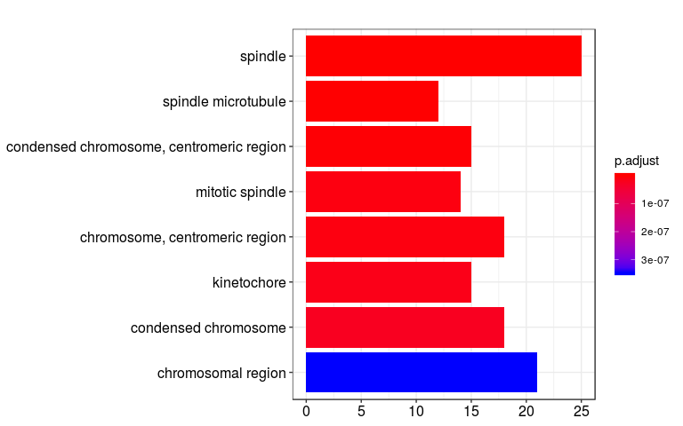

```r
barplot(ego, showCategory=8)
```

## dotplot

[dotplot](http://guangchuangyu.github.io/2015/06/dotplot-for-enrichment-result/) is a good alternative to `barplot`.

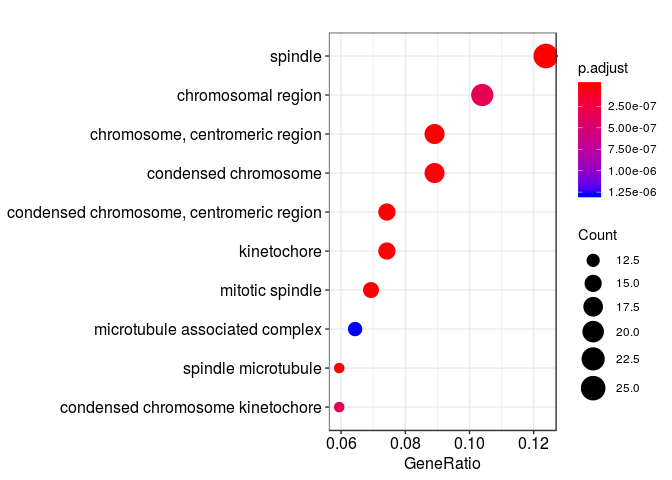

```r
dotplot(ego)
```

## emapplot

Enrichment map can be viusalized by `emapplot`, which also support results obtained from hypergeometric test and gene set enrichment analysis.

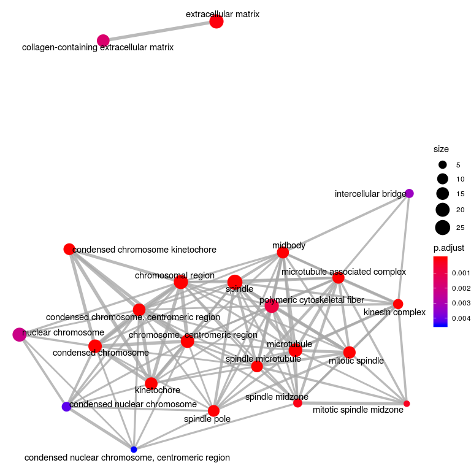

enrichment map of enrichment result

```r
emapplot(ego)
```

## cnetplot

In order to consider the potentially biological complexities in which a gene may belong to multiple annotation categories and provide information of numeric changes if available, we developed `cnetplot` function to extract the complex association.

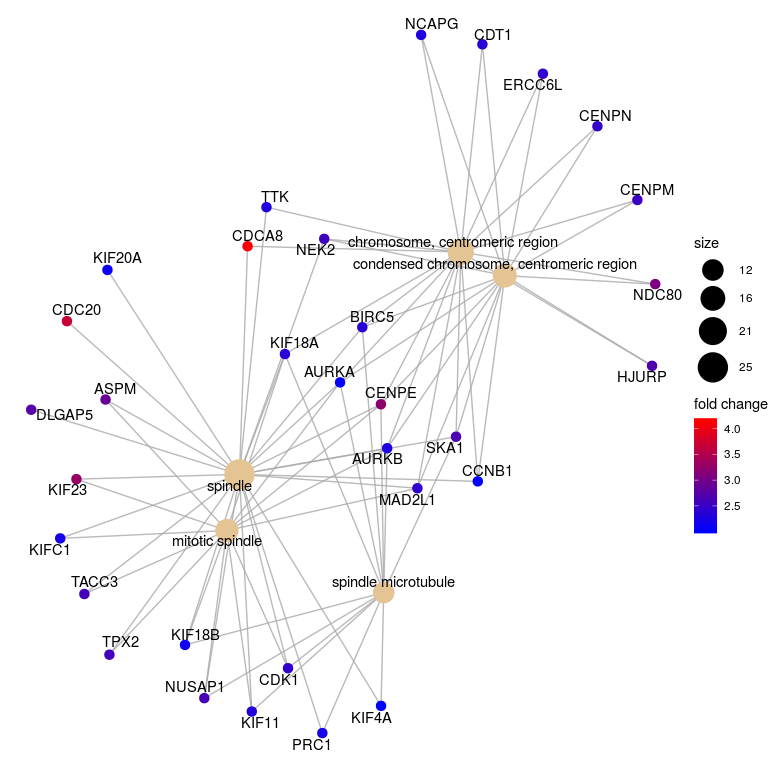

```r
## categorySize can be scaled by 'pvalue' or 'geneNum'
cnetplot(ego, categorySize="pvalue", foldChange=geneList)
```

## goplot

`goplot` can accept output of `enrichGO` and visualized the enriched GO induced graph.

```r
goplot(ego)
```

[output not shown]

## gseaplot

Running score of gene set enrichment analysis and its association of phenotype can be visualized by `gseaplot`.

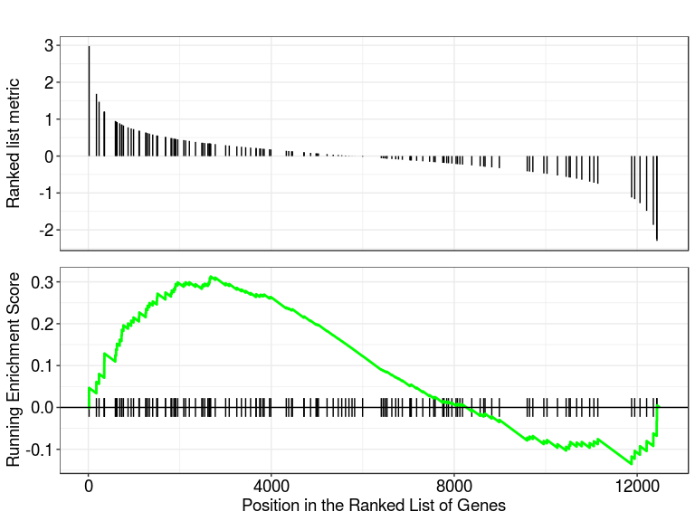

plotting gsea result

```r
gseaplot(kk2, geneSetID = "hsa04145")
```

## browseKEGG

To view the KEGG pathway, user can use `browseKEGG` function, which will open web browser and highlight enriched genes.

```r
browseKEGG(kk, 'hsa04110')
```

[figure not shown]

## pathview from pathview package

clusterProfiler users can also use `pathview` from the pathview(Luo and Brouwer 2013) to visualize KEGG pathway.

The following example illustrate how to visualize “hsa04110” pathway, which was enriched in our previous analysis.

```r
library("pathview")
hsa04110 <- pathview(gene.data  = geneList,
                     pathway.id = "hsa04110",
                     species    = "hsa",
                     limit      = list(gene=max(abs(geneList)), cpd=1))
```

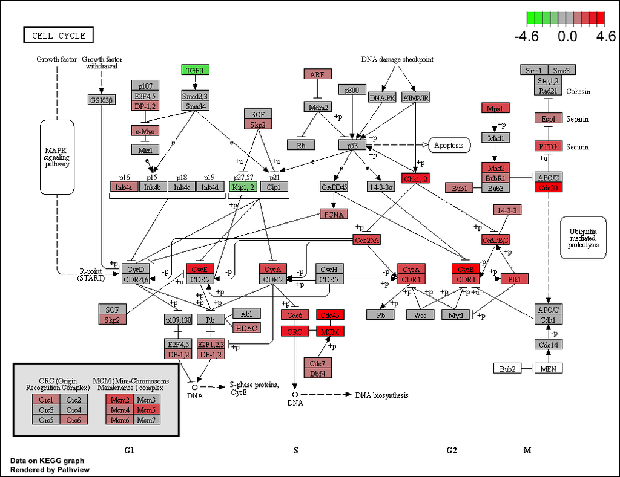

For further information, please refer to the vignette of pathview(Luo and Brouwer 2013).

# Biological theme comparison

clusterProfiler was developed for biological theme comparison(Yu et al. 2012), and it provides a function, `compareCluster`, to automatically calculate enriched functional categories of each gene clusters.

```r
data(gcSample)
lapply(gcSample, head)
```

```
## $X1
## [1] "4597"  "7111"  "5266"  "2175"  "755"   "23046"
##
## $X2
## [1] "23450" "5160"  "7126"  "26118" "8452"  "3675"
##
## $X3
## [1] "894"   "7057"  "22906" "3339"  "10449" "6566"
##
## $X4
## [1] "5573"  "7453"  "5245"  "23450" "6500"  "4926"
##
## $X5
## [1] "5982" "7318" "6352" "2101" "8882" "7803"
##
## $X6
## [1] "5337"  "9295"  "4035"  "811"   "23365" "4629"
##
## $X7
## [1] "2621" "2665" "5690" "3608" "3550" "533"
##
## $X8
## [1] "2665" "4735" "1327" "3192" "5573" "9528"
```

```r
ck <- compareCluster(geneCluster = gcSample, fun = "enrichKEGG")
head(as.data.frame(ck))
```

```
##   Cluster       ID                            Description GeneRatio
## 1      X2 hsa04110                             Cell cycle    18/359
## 2      X2 hsa05169           Epstein-Barr virus infection    23/359
## 3      X2 hsa05340               Primary immunodeficiency     8/359
## 4      X2 hsa04064           NF-kappa B signaling pathway    13/359
## 5      X3 hsa04512               ECM-receptor interaction     9/172
## 6      X3 hsa04060 Cytokine-cytokine receptor interaction    17/172
##    BgRatio       pvalue   p.adjust     qvalue
## 1 124/7469 2.332774e-05 0.00671839 0.00635988
## 2 201/7469 8.929735e-05 0.01285882 0.01217264
## 3  37/7469 2.981427e-04 0.02862170 0.02709438
## 4  95/7469 5.710020e-04 0.04111214 0.03891829
## 5  82/7469 1.022372e-04 0.02566153 0.02389122
## 6 294/7469 4.115636e-04 0.04002781 0.03726641
##                                                                                                      geneID
## 1                   991/1869/890/1871/701/990/10926/9088/8317/9700/9134/1029/2810/699/11200/23594/8555/4173
## 2 4067/3383/7128/1869/890/1871/578/864/637/9641/6891/355/9134/5971/916/956/6850/7187/3551/919/4734/958/6772
## 3                                                                       100/6891/3932/973/916/925/958/64421
## 4                                           4067/3383/7128/3932/5971/4050/6850/7187/3551/10892/5588/330/958
## 5                                                              7057/3339/1299/3695/1101/3679/3910/3696/3693
## 6                      2919/4982/3977/6375/8200/608/8792/3568/2057/1438/8718/655/652/10220/50615/51561/7042
##   Count
## 1    18
## 2    23
## 3     8
## 4    13
## 5     9
## 6    17
```

## Formula interface of compareCluster

`compareCluster` also supports passing a formula (the code to support formula has been contributed by Giovanni Dall’Olio) of type $Entrez \sim group$ or $Entrez \sim group + othergroup$.

```r
mydf <- data.frame(Entrez=names(geneList), FC=geneList)
mydf <- mydf[abs(mydf$FC) > 1,]
mydf$group <- "upregulated"
mydf$group[mydf$FC < 0] <- "downregulated"
mydf$othergroup <- "A"
mydf$othergroup[abs(mydf$FC) > 2] <- "B"

formula_res <- compareCluster(Entrez~group+othergroup, data=mydf, fun="enrichKEGG")

head(as.data.frame(formula_res))
```

```
##           Cluster         group othergroup       ID
## 1 downregulated.A downregulated          A hsa04974
## 2 downregulated.A downregulated          A hsa04510
## 3 downregulated.A downregulated          A hsa04151
## 4 downregulated.A downregulated          A hsa04512
## 5 downregulated.A downregulated          A hsa05414
## 6 downregulated.A downregulated          A hsa04010
##                        Description GeneRatio  BgRatio       pvalue
## 1 Protein digestion and absorption    15/280  90/7469 1.015092e-06
## 2                   Focal adhesion    20/280 199/7469 5.171665e-05
## 3       PI3K-Akt signaling pathway    28/280 354/7469 1.349777e-04
## 4         ECM-receptor interaction    11/280  82/7469 2.210722e-04
## 5     Dilated cardiomyopathy (DCM)    11/280  90/7469 5.036530e-04
## 6           MAPK signaling pathway    23/280 295/7469 6.637675e-04
##       p.adjust       qvalue
```

[output cut: 20 more lines]

## Visualization of profile comparison

We can visualize the result using `dotplot` method.

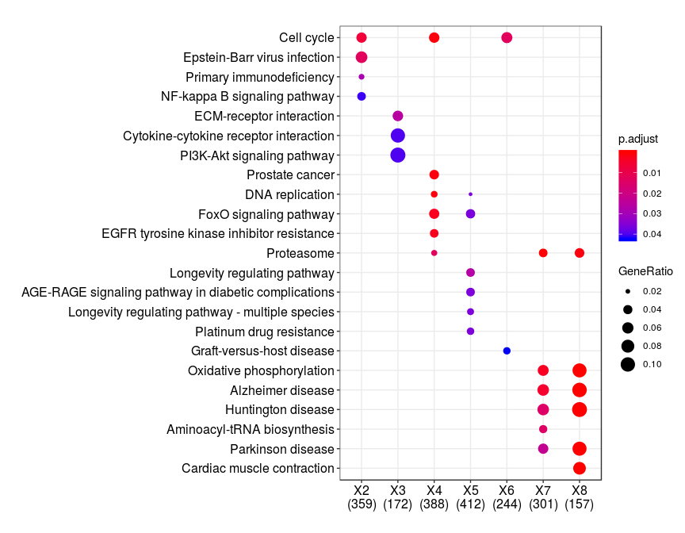

```r
dotplot(ck)
```

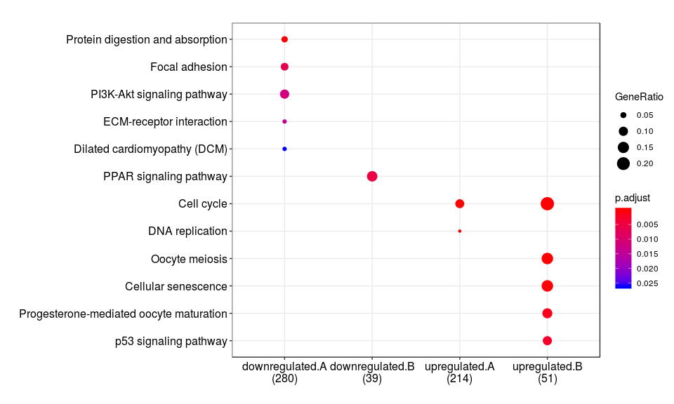

```r
dotplot(formula_res)
```

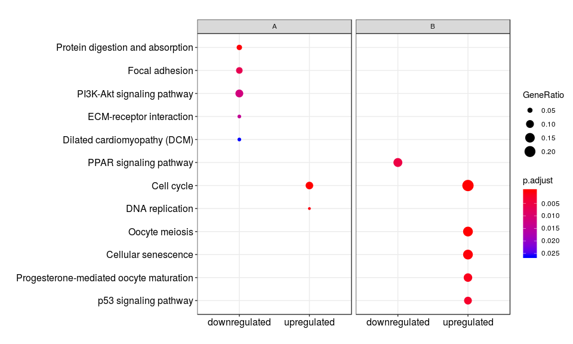

```r
dotplot(formula_res, x=~group) + ggplot2::facet_grid(~othergroup)
```

By default, only top 5 (most significant) categories of each cluster was plotted. User can changes the parameter *showCategory* to specify how many categories of each cluster to be plotted, and if *showCategory* was set to *NULL*, the whole result will be plotted.

The *plot* function accepts a parameter *by* for setting the scale of dot sizes. The default parameter *by* is setting to “geneRatio”, which corresponding to the “GeneRatio” column of the output. If it was setting to *count*, the comparison will be based on gene counts, while if setting to *rowPercentage*, the dot sizes will be normalized by *count/(sum of each row)*

The p-values indicate that which categories are more likely to have biological meanings. The dots in the plot are color-coded based on their corresponding p-values. Color gradient ranging from red to blue correspond to in order of increasing p-values. That is, red indicate low p-values (high enrichment), and blue indicate high p-values (low enrichment). P-values and adjusted p-values were filtered out by the threshold giving by parameter *pvalueCutoff*, and FDR can be estimated by *qvalue*.

User can refer to the example in Yu (2012)(Yu et al. 2012); we analyzed the publicly available expression dataset of breast tumour tissues from 200 patients (GSE11121, Gene Expression Omnibus)(Schmidt et al. 2008). We identified 8 gene clusters from differentially expressed genes, and using `compareCluster` to compare these gene clusters by their enriched biological process.

The comparison function was designed as a framework for comparing gene clusters of any kind of ontology associations, not only `groupGO`, `enrichGO`, `enrichKEGG` and `enricher` provided in this package, but also other biological and biomedical ontologies, for instance, `enrichDO` from DOSE(Yu et al. 2015), `enrichMeSH` from meshes and `enrichPathway` from ReactomePA work fine with `compareCluster` for comparing biological themes in disease and reactome pathway perspective. More details can be found in the vignettes of DOSE(Yu et al. 2015) and ReactomePA.

# Need helps?

If you have questions/issues, please visit [clusterProfiler homepage](https://guangchuangyu.github.io/software/clusterProfiler/) first. Your problems are mostly documented. If you think you found a bug, please follow [the guide](https://guangchuangyu.github.io/2016/07/how-to-bug-author/) and provide a reproducible example to be posted on [github issue tracker](https://github.com/GuangchuangYu/clusterProfiler/issues). For questions, please post to [Bioconductor support site](https://support.bioconductor.org/) and tag your post with *clusterProfiler*.

# References

A., Omer, Giovanni M. D., Thanos P. M., and Francesca D. C. 2016. “NCG 5.0: Updates of a Manually Curated Repository of Cancer Genes and Associated Properties from Cancer Mutational Screenings.” *Nucleic Acids Research* 44 (D1):D992–D999. https://doi.org/10.1093/nar/gkv1123.

Boyle, Elizabeth I, Shuai Weng, Jeremy Gollub, Heng Jin, David Botstein, J Michael Cherry, and Gavin Sherlock. 2004. “GO::TermFinder–open Source Software for Accessing Gene Ontology Information and Finding Significantly Enriched Gene Ontology Terms Associated with a List of Genes.” *Bioinformatics (Oxford, England)* 20 (18):3710–5. https://doi.org/10.1093/bioinformatics/bth456.

Fresno, Cristóbal, and Elmer A. Fernández. 2013. “RDAVIDWebService: A Versatile R Interface to DAVID.” *Bioinformatics* 29 (21):2810–1. https://doi.org/10.1093/bioinformatics/btt487.

Huang, Da, Brad T Sherman, Qina Tan, Jack R Collins, W Gregory Alvord, Jean Roayaei, Robert Stephens, Michael W Baseler, H Clifford Lane, and Richard A Lempicki. 2007. “The DAVID Gene Functional Classification Tool: A Novel Biological Module-Centric Algorithm to Functionally Analyze Large Gene Lists.” *Genome Biology* 8 (9):R183. https://doi.org/10.1186/gb-2007-8-9-r183.

Janet, P., Núria Q.R., Àlex B., Jordi D.P., Anna B.M., Martin B., Ferran S., and Laura I. F. 2015. “DisGeNET: A Discovery Platform for the Dynamical Exploration of Human Diseases and Their Genes.” *Database* 2015 (March):bav028. https://doi.org/10.1093/database/bav028.

Luo, Weijun, and Cory Brouwer. 2013. “Pathview: An R/Bioconductor Package for Pathway-Based Data Integration and Visualization.” *Bioinformatics* 29 (14):1830–1. https://doi.org/10.1093/bioinformatics/btt285.

Schmidt, Marcus, Daniel B?hm, Christian von T?rne, Eric Steiner, Alexander Puhl, Henryk Pilch, Hans-Anton Lehr, Jan G. Hengstler, Heinz K?lbl, and Mathias Gehrmann. 2008. “The Humoral Immune System Has a Key Prognostic Impact in Node-Negative Breast Cancer.” *Cancer Research* 68 (13):5405–13. https://doi.org/10.1158/0008-5472.CAN-07-5206.

Subramanian, Aravind, Pablo Tamayo, Vamsi K. Mootha, Sayan Mukherjee, Benjamin L. Ebert, Michael A. Gillette, Amanda Paulovich, et al. 2005. “Gene Set Enrichment Analysis: A Knowledge-Based Approach for Interpreting Genome-Wide Expression Profiles.” *Proceedings of the National Academy of Sciences of the United States of America* 102 (43):15545–50. https://doi.org/10.1073/pnas.0506580102.

Yu, Guangchuang, and Qing-Yu He. 2016. “ReactomePA: An R/Bioconductor Package for Reactome Pathway Analysis and Visualization.” *Molecular BioSystems* 12 (2):477–79. https://doi.org/10.1039/C5MB00663E.

Yu, Guangchuang, Fei Li, Yide Qin, Xiaochen Bo, Yibo Wu, and Shengqi Wang. 2010. “GOSemSim: An R Package for Measuring Semantic Similarity Among Go Terms and Gene Products.” *Bioinformatics* 26 (7):976–78. https://doi.org/10.1093/bioinformatics/btq064.

Yu, Guangchuang, Le-Gen Wang, Yanyan Han, and Qing-Yu He. 2012. “ClusterProfiler: An R Package for Comparing Biological Themes Among Gene Clusters.” *OMICS: A Journal of Integrative Biology* 16 (5):284–87. https://doi.org/10.1089/omi.2011.0118.

Yu, Guangchuang, Li-Gen Wang, and Qing-Yu He. 2015. “ChIPseeker: An R/Bioconductor Package for Chip Peak Annotation, Comparison and Visualization.” *Bioinformatics* 31 (14):2382–3. https://doi.org/10.1093/bioinformatics/btv145.

Yu, Guangchuang, Li-Gen Wang, Guang-Rong Yan, and Qing-Yu He. 2015. “DOSE: An R/Bioconductor Package for Disease Ontology Semantic and Enrichment Analysis.” *Bioinformatics* 31 (4):608–9. https://doi.org/10.1093/bioinformatics/btu684.